# Matplotlib

This project is all about Matplotlib, the basic data visualization tool of Python programming language. I have discussed Matplotlib object hierarchy, various plot types with Matplotlib and customization techniques associated with Matplotlib.

This project is divided into various sections based on contents which are listed below:-

1. Introduction
2. Overview of Python Data Visualization Tools
3. Introduction to Matplotlib
4. Import Matplotlib
5. Displaying Plots in Matplotlib
6. Matplotlib Object Hierarchy
7. Matplotlib interfaces
8. Pyplot API
9. Object-Oriented API
10. Figure and Subplots
11. First plot with Matplotlib
12. Multiline Plots
13. Parts of a Plot
14. Saving the Plot
15. Line Plot
16. Scatter Plot
17. Histogram
18. Bar Chart
19. Horizontal Bar Chart
20. Error Bar Chart
21. Stacked Bar Chart
22. Pie Chart
23. Box Plot
24. Area Chart
25. Contour Plot
26. Styles with Matplotlib Plots
27. Adding a grid
28. Handling axes
29. Handling X and Y ticks
30. Adding labels
31. Adding a title
32. Adding a legend
33. Control colours
34. Control line styles
35. Summary

## 1. Introduction

When we want to convey some information to others, there are several ways to do so. The process of conveying the information with the help of plots and graphics is called **Data Visualization**. The plots and graphics take numerical data as input and display output in the form of charts, figures and tables. It helps to analyze and visualize the data clearly and make concrete decisions. It makes complex data more accessible and understandable. The goal of data visualization is to communicate information in a clear and efficient manner.

In this project, I shed some light on **Matplotlib**, which is the basic data visualization tool of Python programming language. Python has different data visualization tools available which are suitable for different purposes. First of all, I will list these data visualization tools and then I will discuss Matplotlib.

## 2. Overview of Python Visualization Tools

Python is the preferred language of choice for data scientists. Python have multiple options for data visualization. It has several tools which can help us to visualize the data more effectively. These Python data visualization tools are as follows:-

• Matplotlib

• Seaborn

• pandas

• Bokeh

• Plotly - R PROGRAMING PACKAGE

• ggplot - R PROGRAMING PACKAGE

• pygal - R programing pacakge

In the following sections, I discuss Matplotlib as the data visualization tool.

## 3. Introduction to Matplotlib

**Matplotlib** is the basic plotting library of Python programming language. It is the most prominent tool among Python visualization packages. Matplotlib is highly efficient in performing wide range of tasks. It can produce publication quality figures in a variety of formats. It can export visualizations to all of the common formats like PDF, SVG, JPG, PNG, BMP and GIF. It can create popular visualization types – line plot, scatter plot, histogram, bar chart, error charts, pie chart, box plot, and many more types of plot. Matplotlib also supports 3D plotting. Many Python libraries are built on top of Matplotlib. For example, pandas and Seaborn are built on Matplotlib. They allow to access Matplotlib’s methods with less code.

The project **Matplotlib** was started by John Hunter in 2002. Matplotlib was originally started to visualize Electrocorticography (ECoG) data of epilepsy patients during post-doctoral research in Neurobiology. The open-source tool Matplotlib emerged as the most widely used plotting library for the Python programming language. It was used for data visualization during landing of the Phoenix spacecraft in 2008.

## 4. Import Matplotlib

Before, we need to actually start using Matplotlib, we need to import it. We can import Matplotlib as follows:-

`import matplotlib`

Most of the time, we have to work with **pyplot** interface of Matplotlib. So, I will import **pyplot** interface of Matplotlib as follows:-

`import matplotlib.pyplot`

To make things even simpler, we will use standard shorthand for Matplotlib imports as follows:-

`import matplotlib.pyplot as plt`

```python
# Import dependencies

import numpy as np
import pandas as pd
```

```python
# Import Matplotlib

import matplotlib.pyplot as plt
```

## 5. Displaying Plots in Matplotlib

Viewing the Matplotlib plot is context based. The best usage of Matplotlib differs depending on how we are using it. There are three applicable contexts for viewing the plots. The three applicable contexts are using plotting from a script, plotting from an IPython shell or plotting from a Jupyter notebook.

### Plotting from a script

If we are using Matplotlib from within a script, then the **plt.show()** command is of great use. It starts an event loop, looks for all currently active figure objects, and opens one or more interactive windows that display the figure or figures.

The **plt.show()** command should be used only once per Python session. It should be used only at the end of the script. Multiple **plt.show()** commands can lead to unpredictable results and should mostly be avoided.

### Plotting from an IPython shell

We can use Matplotlib interactively within an IPython shell. IPython works well with Matplotlib if we specify Matplotlib mode. To enable this mode, we can use the **%matplotlib** magic command after starting ipython. Any plt plot command will cause a figure window to open and further commands can be run to update the plot.

### Plotting from a Jupyter notebook

The Jupyter Notebook (formerly known as the IPython Notebook) is a data analysis and visualization tool that provides multiple tools under one roof. It provides code execution, graphical plots, rich text and media display, mathematics formula and much more facilities into a single executable document.

Interactive plotting within a Jupyter Notebook can be done with the **%matplotlib** command. There are two possible options to work with graphics in Jupyter Notebook. These are as follows:-

• **%matplotlib notebook** – This command will produce interactive plots embedded within the notebook.

• **%matplotlib inline** – It will output static images of the plot embedded in the notebook.

After this command (it needs to be done only once per kernel per session), any cell within the notebook that creates a plot will embed a PNG image of the graphic.

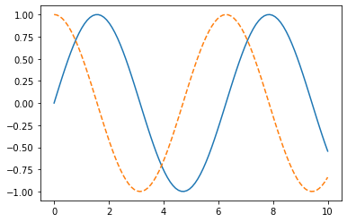

```python
%matplotlib inline


x1 = np.linspace(0, 10, 100)


# create a plot figure
fig = plt.figure()

plt.plot(x1, np.sin(x1), '-')
plt.plot(x1, np.cos(x1), '--');
```